# QuiPT Quick Permutation Test

Lipiec 2020

## Wstęp

QuiPT jest algorytmem selekcji cech (n-gramów) opartym o dokładny test Fishera.

[interactive chart not shown]

## Redukcja nieinformatywnych n-gramów

Filtrowane są n-gramy, które występują:

- tylko raz
- w każdym n-gramie

## Tablica wielodzielcza (kontyngencji)

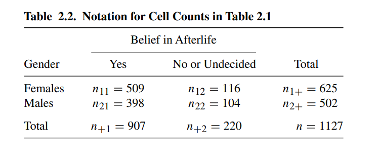

Źródło: A. Agresti, An introduction to categorical data analysis

## Dokładny Test Fishera

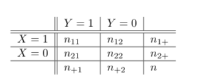

\[ H_0 : \pi_{11} = \pi_{1+} \pi_{+1} \] \[ H_A : \pi_{11} \neq \pi_{1+} \pi_{+1} \]

- \(\pi_{11}\) - prawdopodobieństwo wystąpienia obserwacji \(X = 1; Y=1\)
- Estymatorem \(\pi_{11}\) jest frakcja z próby: \(\hat{\pi}_{11} = n_{11} / n\)
- Rozkład \(\pi_{11}\) przy \(H_0\) ma rozkład hipergeometryczny

## Eksperyment Fishera

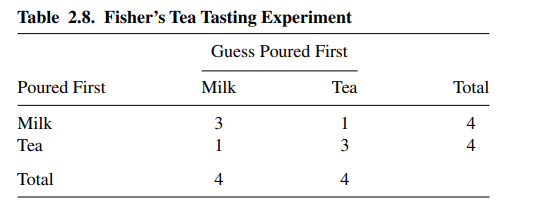

Potencjalne wartości \(n_{11}: \{0, 1, 2, 3, 4\}\):

\[P(3) = 0.229;~ P(4) = 0.014;\] \[p-value = P(3) + P(4) = 0.243\]

## Information Gain

\[ IG(Ex, a) = H(Ex) - \Sigma_{v \in values(a)}\bigg[\frac{|x\in Ex | value(x, a) = v|}{|Ex|} \] \[ \times H(\{x \in Ex | value(x, a) = v\})\bigg] \]

- \(H\) - entropia
- \(Ex\) - zbiór obserwacji
- \(a\) - zmienna
- \(value(x,a)\) - wartość obserwacji \(x \in Ex\) dla zmiennej \(a\)

## Test Fishera - n-gramy

Jeśli \(n_{11}\leq200\), stosowany jest dokładny test Fishera, oparty o Information Gain

Jeśli \(n_{11}>200\), stosowane jest podejście Monte Carlo:

- Siatka punktów długości 200
- Information Gain
- Przybliżona p-wartość

## Test Fishera - n-gramy cd.

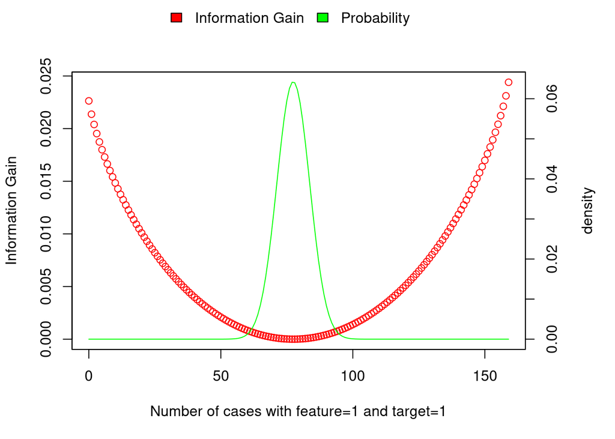

## Wielokrotne testowanie

\[ Q = \frac{V}{R} \] \[ FDR = \mathcal{E}Q \]

- \(V\) - false discovery (błąd pierwszego rodzaju)
- \(R\) - all discoveries
- \(FDR\) - Oczekiwana frakcja błędnych odrzuceń \(H_0\)

## Procedura Benjamini-Hochberga

Poprawka BH kontroluje \(FDR\), tak by \(FDR \leq \alpha\), gdzie \(\alpha\) jest poziomem istotności przeprowadzanych testów.

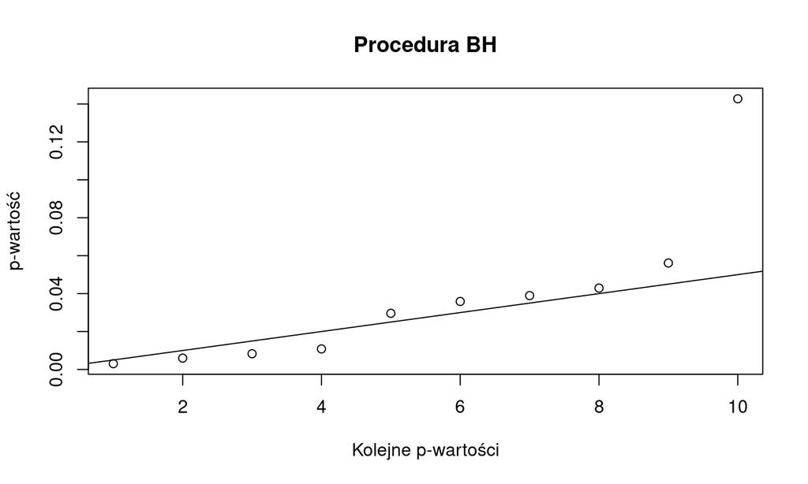

## Literatura

- A. Agresti, An introduction to categorical data analysis
- M. Burdukiewicz et al., Amyloidogenic motifs revealed by n-gram analysis
- Y. Benjamini, Discovering the false discovery rate